# Supplementary File 6. OBO Foundry gallery

Zuguang Gu ( z.gu@dkfz.de )

2023-11-27

[OBO Foundry](http://obofoundry.org/) is a database of public biological ontologies. In this document, we import all ontologies on OBO Foundry and generate circular visualization, similarity heatmap and runtime performance on them.

Columns in the table:

- `id`: ID of the ontology.
- `title`: Title of the ontology.
- `n_terms`: Number of terms.
- `n_relations`: Number of relations.
- `is_tree`: Whether the DAG is a tree. The DAG is a tree if n_terms == n_relations + 1.
- `pa_avg`: Average number of parent terms.
- `ch_avg`: Average number of child terms.
- `asp1`: `width/height`, where `width` is the largest number of terms on a specific distance to root (i.e. `max(table(largest_dist_to_root(dag)))`). `height` is the 99% percentile of heights of all terms.
- `asp2`: `width/height`, where `width` is the largest number of terms on a specific distance to root (i.e. `max(table(shortest_dist_to_root(dag)))`). `height` is the 99% percentile of heights of all terms.
- `d_max`: Maximal depth of terms.

Script for formatting the table and generating the plots is OBOFoundry.R.

| id | title | n_terms | n_relations | is_tree | pa_avg | ch_avg | asp1 | asp2 | d_max |
| --- | --- | --- | --- | --- | --- | --- | --- | --- | --- |
| ncbitaxon | NCBI organismal classification [image] | 2511801 | 2511800 | tree | 1 | 11.1 | 6555.26 | 6555.26 | -1 |
| dron | The Drug Ontology [image] | 672410 | 678101 |  | 1 | 21.1 | 45235.69 | 53996.18 | -1 |
| pr | PRotein Ontology (PRO) [image] | 329429 | 419927 |  | 1.3 | 6 | 7762.62 | 17486.29 | -1 |
| ncit | NCI Thesaurus OBO Edition [image] | 169222 | 194204 |  | 1.1 | 6.3 | 2478.85 | 3275.45 | -1 |
| chebi | Chemical Entities of Biological Interest [image] | 164807 | 238469 |  | 1.4 | 18.4 | 1657 | 2912.43 | -1 |
| gno | Glycan Naming and Subsumption Ontology (GNOme) [image] | 153907 | 202548 |  | 1.3 | 1.9 | 2407.42 | 4409.75 | -1 |
| vto | Vertebrate Taxonomy Ontology [image] | 107061 | 107060 | tree | 1 | 4.7 | 564.8 | 564.8 | -1 |
| fma | Foundational Model of Anatomy Ontology (subset) [image] | 78978 | 78977 | tree | 1 | 3.1 | 707.59 | 707.59 | -1 |
| ogg | The Ontology of Genes and Genomes [image] | 69688 | 69687 | tree | 1 | 819.8 | 4593.8 | 4593.8 | -1 |
| zp | Zebrafish Phenotype Ontology [image] | 58978 | 89020 |  | 1.5 | 4.1 | 440.95 | 610.62 | -1 |

[output cut: 197 more lines]

### Plots for ontology: [ado](http://obofoundry.org/ontology/ado.html) <ado.owl>

- Circular visualization
- Similarity heatmap
- Runtime

```
# the circular visualization is generated by:
dag_circular_viz(dag, partition_by_size = round(dag_n_terms(dag)/5))
```

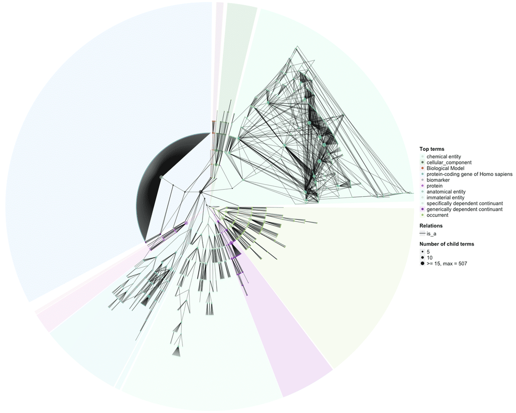